# Differential Expression Report

Project: Differential Gene Expression and Pulmonary Function in Vaping LatinX Adolescents Analyst: Trent Hawkins Investigator(s): Sunita Sharma, MD Report generated: May 06, 2022

# Background

The data presented in this report are part of a study aimed to assess differential gene expression and methylation in vaping versus non-vaping LatinX youths in Pueblo and Denver, CO. Pulmonary function data were also obtained in order to better understand the impacts of vape use on pulmonary function. To assess differential gene expression and methylation, naso-epithelial swabs were obtained from each participating subject. Pulmonary function is assessed using PFTs (Pulmonary Function Tests) and Impulse Oscillometry (IOS).

# Study Population

This data set consists of samples taken from 51 people ages 12-17 yrs from the Pueblo, Denver, and Aurora, CO areas. Vape Status (did you vape in the last 6 months?) and ethnicity are self-reported.

# Methods

*All analyses performed using R version 4.1.2 (2021-11-01)*

### Clinical Data Processing

Subjects are dichotomized to those that used a vaping device in the last 6 months and those who have not based on the variables *ever_vape*, *vape_days*, and *last_vape*. This variable will be referred to as *Vape Status* throughout this report. One participant (SID = 111) reported that they had used a vaping device 5 out of the last 30 days, but did not respond to *last_vape*. That participant is recorded as *Vaped* in this analysis. Biological sex has been derived from methylation data utilizing the getSex function from the R package *minfi 1.40.0*.

Subjects’ geographic location, *city*, was grouped into the new broader variable *recruiting_center* which encompasses the broader geographic region where they live.

Measures of lung function and IOS were visually inspected for normality using histograms. To test for correlation, a contingency table was made for each comparison of variables. because some contingency tables contained cells with <5 subjects, a Fisher’s Exact test was used for all tests.

### Gene-Count Processing

*Annotation: Ensembl annotation for GrCH 39 ver. 37*  
*Removal of Unwanted Variance: edgeR 3.36.0 and RUVSeq 1.28.0*  
*Differential Expression Analysis: DESeq2 1.34.0*

*Filtering*  
To arrive at the final number of genes for this analysis, we first removed all genes with 0-counts in 75% or more of the samples. In addition, we removed genes which had a range of reads $\le$ 100 across all samples or ‘housekeeping genes’.

*Normalization*  
The following analyses used the function RUVr from the R package RUVSeq. RUVr uses the deviance residuals from a first pass negative binomial GLM to perform a factor analysis which corrects for unwanted technical effects. The first-pass model includes vape status, sex, and age.

$$raw \ read \ count \sim vape \ status \ + sex + age$$

### Model Fitting

The differential expression analysis will use RUVr with k = 2 factors. Gene counts were fit using negative binomial models from the R package DESeq2 1.34.0. To account for multiple testing the False Discovery Rate (FDR) was calculated and significance set at FDR < 0.05.

To parse out the effects that vape status and recruitment center have on gene expression, the following models were fit and compared using Likelihood Ratio Tests (LRTs) in DESeq2 1.34.0:

$$Full \ Model \\ raw \ read \ count \sim vape \ status + recruitment \ center + sex + age + ruv_1 + ruv_2$$
$$Reduced \ Model \ (Vape \ Status \ and \ Recruitment \ Center) \\ raw \ read \ count \sim \ sex + age + ruv_1 + ruv_2$$
$$Reduced \ Model \ (Vape \ Status) \\ raw \ read \ count \sim recruitment \ center + sex + age + ruv_1 + ruv_2$$
$$Reduced \ Model \ (Recruitment \ Center) \\ raw \ read \ count \sim vape \ status + sex + age + ruv_1 + ruv_2$$

All LRTs used the same full model, which included vape status (binary Y/N) and recruitment center (3-level categorical), sex (binary M/F), age (continuous), and two normalization factors from the RUVr Analysis. In each scenario above, DESeq2 tests if the covariates included in the full model but *not* the recuded model significantly explain gene expression. The reduced model for vape status and recrutment center tests if either vape status or recruitment center significantly explain gene expression after adjusting for sex, age, and the two RUV factors. The other models test similarly, but only for covariate at a time.

# Results

After removing participants with missing values for vape status, we are left with **n = 50** subjects. Previous analyses showed **n = 12** participants had vaped in the last 6 months. This analysis will use **n = 13** participants who had vaped in the last 6 months. The lung function variable ‘fev1’ and ‘fev1_fvc’ reported 22 missing values. IOS measures ‘r5’ and ‘x20’ reported 1 and 6 missing values, respectively.

### Table 1: Subject Demographics

|  | Did Not Vape in Last 6 Months (N=37) | Vaped in Last 6 Months (N=13) | Total (N=50) |
| --- | --- | --- | --- |
| **Sex** |  |  |  |
| Female | 21 (56.8%) | 5 (38.5%) | 26 (52.0%) |
| Male | 16 (43.2%) | 8 (61.5%) | 24 (48.0%) |
| **Age (yrs)** |  |  |  |
| Mean (SD) | 14.6 (1.4) | 14.8 (1.4) | 14.6 (1.4) |
| Range | 12.0 - 17.0 | 13.0 - 17.0 | 12.0 - 17.0 |
| **Recruitment Center** |  |  |  |
| Aurora | 15 (40.5%) | 0 (0.0%) | 15 (30.0%) |
| CommCity/Denver | 13 (35.1%) | 1 (7.7%) | 14 (28.0%) |
| Pueblo | 9 (24.3%) | 12 (92.3%) | 21 (42.0%) |
| **Ethnicity** |  |  |  |
| LatinX | 23 (62.2%) | 11 (84.6%) | 34 (68.0%) |
| Non-LatinX | 14 (37.8%) | 2 (15.4%) | 16 (32.0%) |
| **FEV1** |  |  |  |
| N-Miss | 10 | 12 | 22 |
| Mean (SD) | 2.6 (0.7) | 3.9 (NA) | 2.6 (0.7) |
| Range | 1.2 - 3.9 | 3.9 - 3.9 | 1.2 - 3.9 |
| **FEV1/FVC (%)** |  |  |  |
| N-Miss | 10 | 12 | 22 |
| Mean (SD) | 0.8 (0.1) | 0.7 (NA) | 0.8 (0.1) |
| Range | 0.5 - 1.0 | 0.7 - 0.7 | 0.5 - 1.0 |
| **R5** |  |  |  |
| N-Miss | 1 | 0 | 1 |
| Mean (SD) | 4.0 (0.9) | 5.0 (1.3) | 4.3 (1.1) |
| Range | 2.0 - 6.1 | 3.7 - 7.6 | 2.0 - 7.6 |
| **X20** |  |  |  |
| N-Miss | 4 | 2 | 6 |
| Mean (SD) | 0.1 (0.6) | 0.7 (0.9) | 0.2 (0.7) |
| Range | -1.1 - 2.4 | -1.0 - 2.3 | -1.1 - 2.4 |

### Figure 1: Select Subject Demographics by Vape Status

The majority of vaping subjects were recruited in Pueblo (92%) and identified as LatinX (85%). 62% of subjects were male as confirmed from the available methylation data.

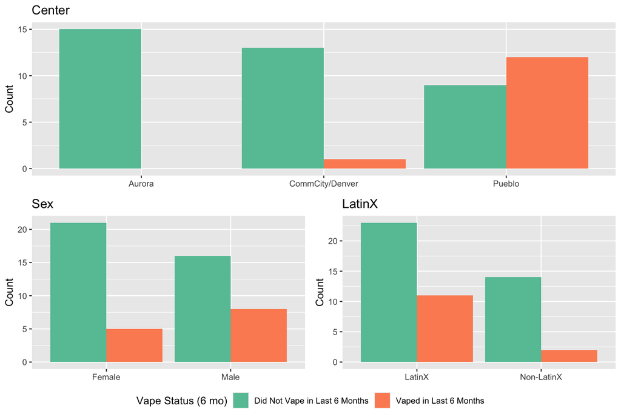

### Figure 2: Pulmonary Function Values by Vape Status

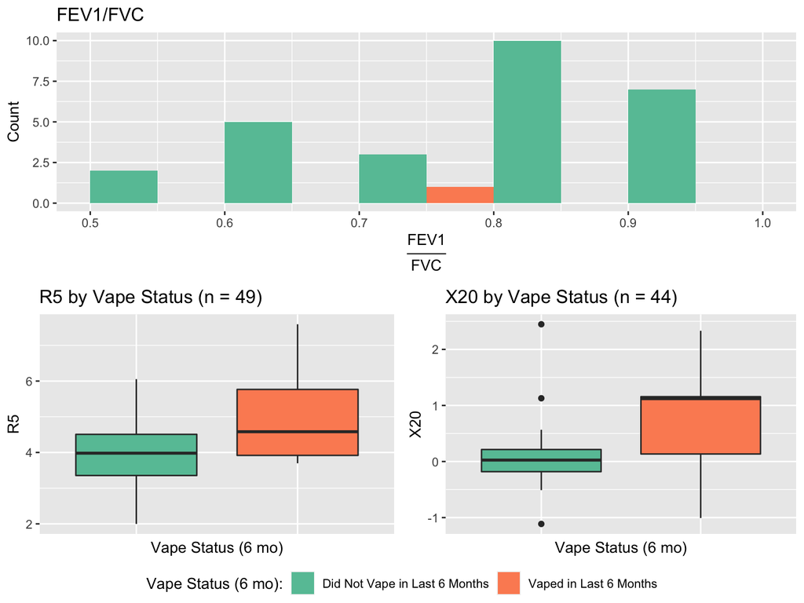

### Figure 3: Correlation of Model Predictors

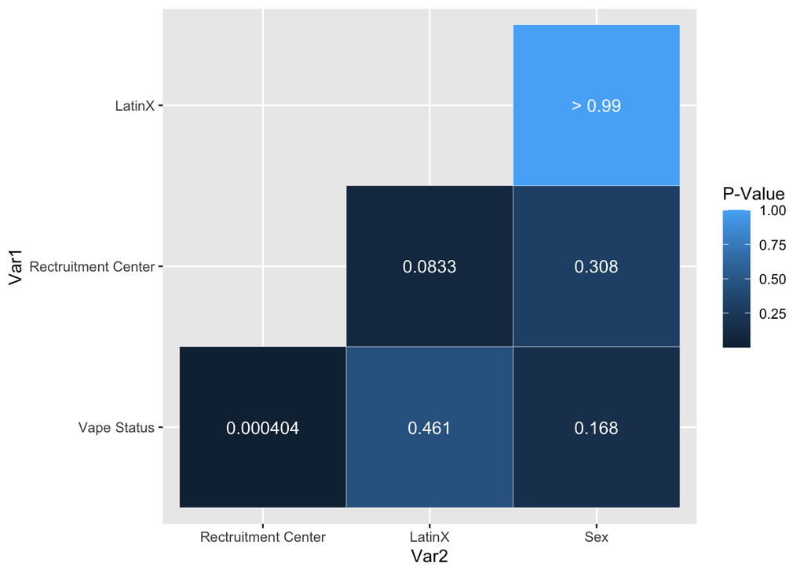

There is a significant correlation between vape status and recruitment center (p < 0.05). The t-test for vape status and age (p = 0.522) shows no significant correlation.

*t-test: Vape Status and Age*

| Test Variable | Group 1 | Group 2 | Mean Group 1 | Mean Group 2 | t | df | p-value |
| --- | --- | --- | --- | --- | --- | --- | --- |
| Age | Did Not Vape in Last 6 Months | Vaped in last 6 months | 14.6 | 14.9 | -0.7 | 16.6 | 0.5 |

## Gene-Count Processing

There were **n = 47** samples present with both demographic and RNA-Seq data (see the Exploratory Report for further details). There were n = 60,651 genes before filtering out poor-quality genes. This analysis will include a total of **n = 16,860** genes.

### Figure 4: Relative Log Expression and Principal Component Analysis for RUV

The Relative Log Expression (RLE) and Principal Component Analysis (PCA) of read counts for each sample both before and after transformation using RUVr with k = 2 factors. There is initial concern for Sample 12 as an outlier.

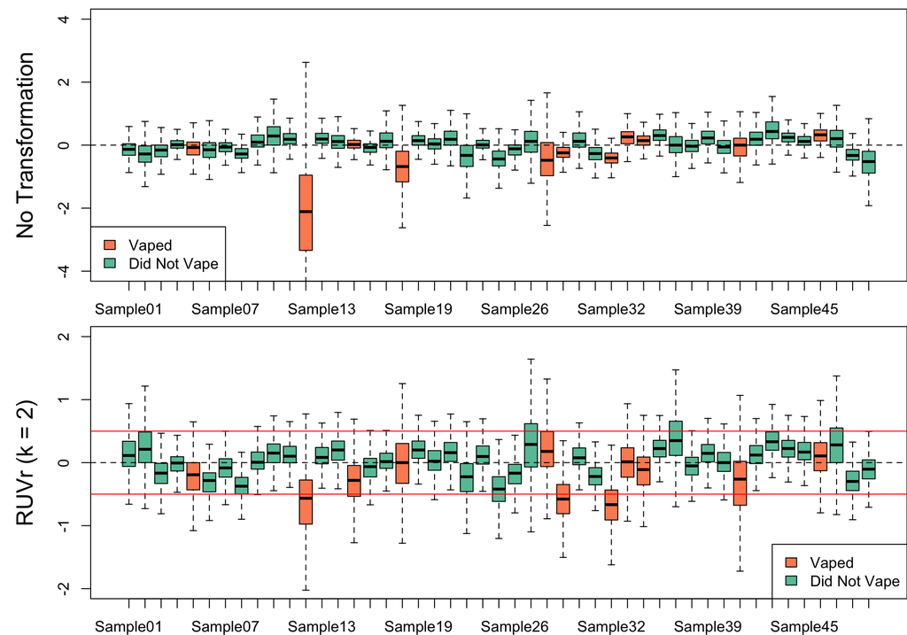

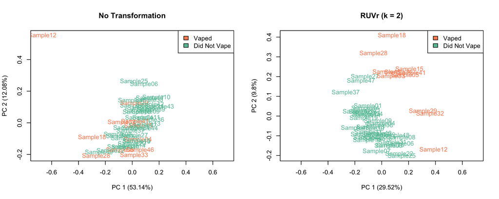

Using two normalization factors, Sample 12 is no longer a suspected outlier and overall two factors sufficiently normalize the gene expression counts.

## Differential Gene Expression Analysis

### Figure 5: P-value Distrobutions (Unadjusted)

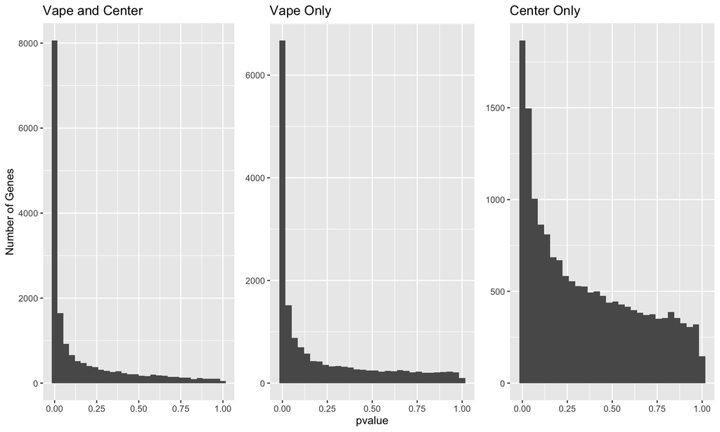

There appears to be a large peak near 0 for all models, but the *Center Only* model is considerably more conservative than the others. The peaks in the *Vape and Center* and *Vape Only* models are unusually high. Overall, there is no evidence for poor model fit. Table 3 shows shows both the total number of significant genes for each mode (FDR < 0.05) followed by the number of genes that were significant in only that model (FDR < 0.05). The *Center Only* model had 0 unique significant genes.

*Table 3: Summary of Significant LRT Results (Full Model the same across all tests)*

| Model | Total Significant Genes (FDR < 0.05) | Unique Significant Genes (FDR < 0.05) |
| --- | --- | --- |
| Vape and Center | 8,581 | 2,013 |
| Vape Only | 6,875 | 629 |
| Center Only | 490 | 0 |

To additionally check model results, Figures 6 - 8 box plots compare $\log_{2}$ transformed expression of the top 4 genes for each model as indicated by the smallest FDR.

### Figures 6: $\log_{2}$(Normalized Expression) of Top Genes (Vape Status and Center)

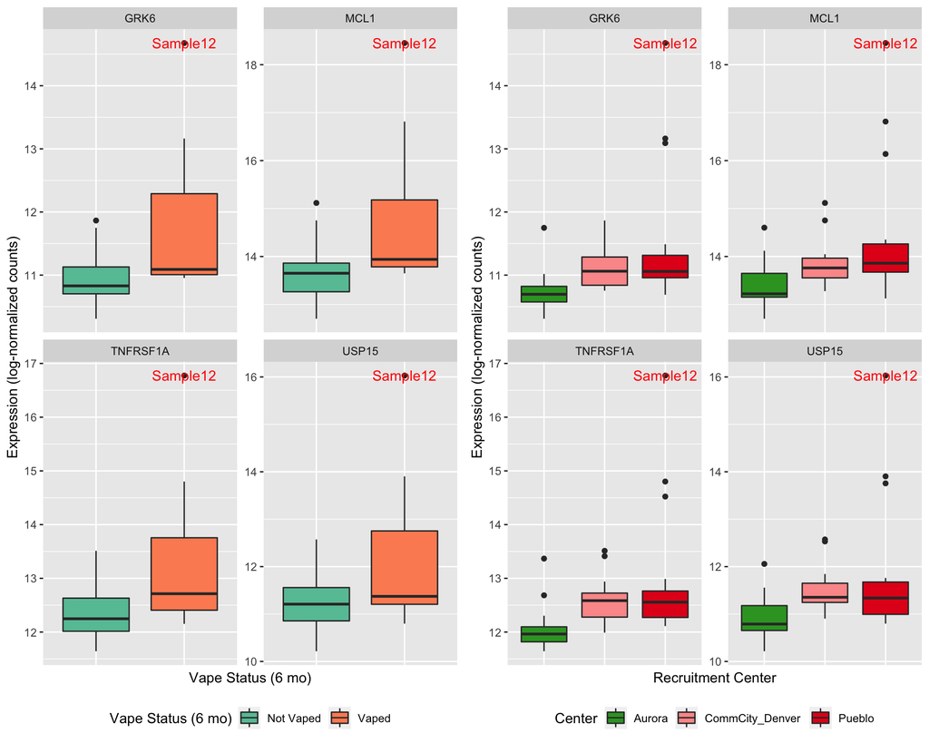

Stratifying by both Vape Status and Recruitment Center using the model results from *Vape and Center* (Figure 6) suggests that there is not a large difference between the groups specified. Additionally, Sample 12 has been highlighted again as a potential outlier that may be driving large variation in the group of vapers from Pueblo.

### Figure 7: $\log_{2}$(Normalized Expression) of Top Genes (Vape Status Only)

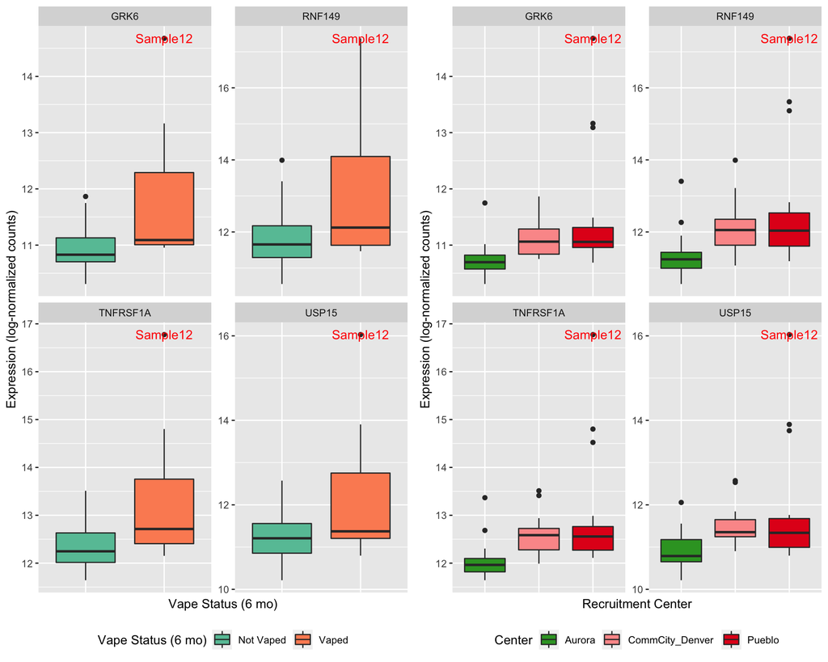

### Figure 8: $\log_{2}$(Normalized Expression) of Top Genes (Center Only)

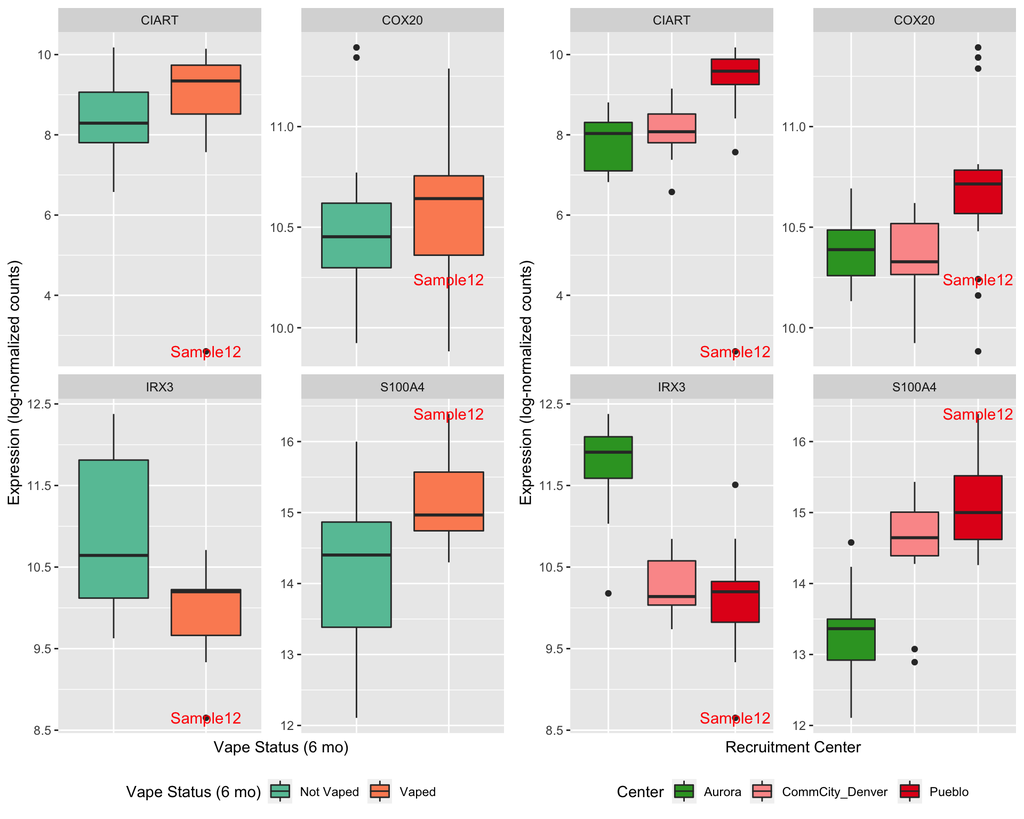

### Figure 9: $\log_{2}$(RUV-Normalized) expression for comparison

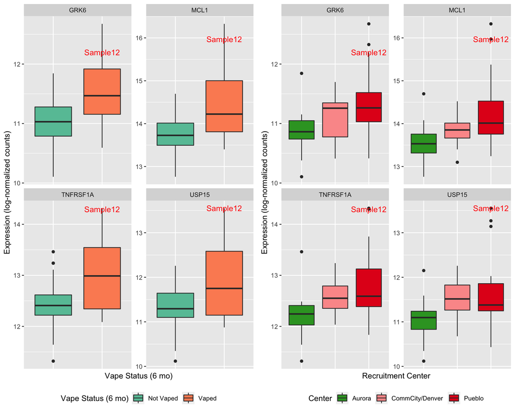

In the plots using RUV-normalized counts, Sample 12 does not show consistently higher expression than all other samples as it does in Figure 6.